# RoboTreasure

## Robot Treasure Algorithms

### Ben Ruland

##### Algorithm 1

The robot moves 10 m out and back, Then 10 meters out and back in the oppostie direction, then 20 each way and so on incrementing by 10 each time.

##### Algorithm 2

Bot travels out 10 meters and then back, repeats in the opposite direction. Then goes out $\large e^{\frac{t}{10}}$ further and then the same distance in the opposite direction, increasing distance exponentially until the energy is found.

##### Some analysis

The starting direction of the robot does matter some if we wish to think in case by case terms. If the energy is on the side the robot starts out on it will reach the energy with less total distance traveled then our following calculations would tell you. However this is just one instance. If we think in terms of the general behavior of the problem, that half the time the energy will be in the opposite direction the robot starts in, then we can say that no it does not matter so much which direction the robot starts for our data to be meaningfull.

Another interesting occurence in these algorithms is that the linear algorithm data set corrseponds to the exponential curve in the graph and the exponential alg data set corrseponds to the linear curve of the graph. This inverse relationship is very intruiging.

##### Coding these algorithms

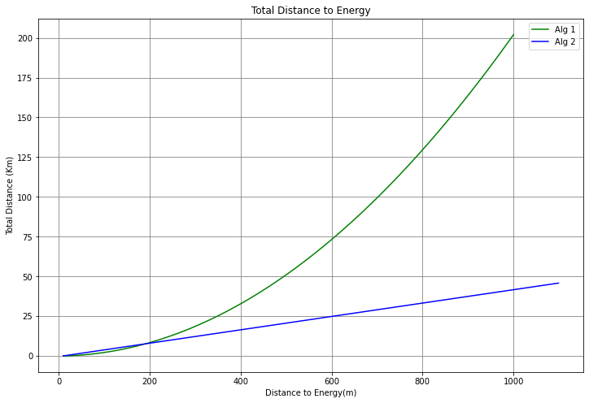

```python
# Thinking of two algorithms to meet the conditions provided in the robot treasure hunt problem
# first algorithm. bot moves 10 m out and back, adding 10 meters on to travel each time it crosses the origin.
# this would look something like,
# increment = 10
# distance reached =increment * numpasses
# distance traveled = (for each iteration) increment*numpasses *4 (this is for out back in both directions)


# Second Algorithm. Bot moves out in a gradually increasing amount each direction, lets say exponential.
# increment = 10*e^numpasses
# distance reached  = needs to be calculated iteratively.
# distance traveled = again iteratively

import numpy as np
from decimal import *
import matplotlib.pyplot as plt



def alg_2(energy_dist):
    '''
    param: energy_dist int
    return  dist_reached_arr numpy array
            dist_total_arr  np array

    calculates the total distance traveled to cover the given distance to energy (params)
    utilizing our second algorithm:
    Bot travels out 10 meters and then back, repeats in the opposite direction.
     Then goes out e**(t/10) further and the same in the opposite direction,
    increasing exponentially until the parameter is met.
    '''
    dist_reached = 0
    increment = 0
    dist_total = 0
    dist_reached_arr = np.array(())
    dist_total_arr = np.array(())
    t = 0
    e = 2.718 #eulers number
    while dist_reached < energy_dist :
        increment = 10*(e**(t/10)) #increasing increment exponentially each time
        dist_total += increment * 4 #accounts for out right +back +out left +back
        dist_reached =increment
        dist_total_entry = dist_total/ 1000 #scaling up array entry to km for ease of reading
        dist_reached_arr = np.append(dist_reached_arr,[dist_reached])
        dist_total_arr = np.append(dist_total_arr,[dist_total_entry])
        t+= 1
     #   print(t)
    #print(increment)
    #print(dist_total)
    return dist_reached_arr, dist_total_arr

def alg_1(energy_dist):
    '''
    params: energy_dist: int
    returns: dist_reached_arr: np array
             dist_total_arr: np arry

    calculates the total distance traveled to cover the given distance to energy (params)
    utilizing our first algorithm:
    robot moves 10 m out and back, Then 10 meters out and back in the oppostie direction,
    then 20 each way and so on incrementing by 10 each time.
    '''
    dist_reached =0
    increment = 10
    dist_total = 0
    dist_reached_arr = np.array(())
    dist_total_arr = np.array(())
    t = 1

    while dist_reached < energy_dist :
        dist_reached = increment * t
        #assuming we are traveling the same dist on both sides of the axis with each pass
        dist_total += 4* dist_reached #accounts for out right +back +out left +back
        #now we are back at the origin ready to repeat
        dist_total_entry = dist_total/1000 # scaling up entry into array to km for ease of reading
        dist_reached_arr = np.append(dist_reached_arr,[dist_reached])
        dist_total_arr= np.append(dist_total_arr,[dist_total_entry])
        t +=1

    #print(dist_reached)
    #print(dist_total)
    return dist_reached_arr, dist_total_arr

def main():

    #calling algorithms to create data
    x,y = alg_1(1000)
    f,z = alg_2(1000)

    #plotting the data
    plt.rcParams['figure.figsize'] = [12, 8]
    fig = plt.figure()
    plot= plt.subplot()
    plot.set(xlabel = "Distance to Energy(m)", ylabel = "Total Distance (Km)", title = "Total Distance to Energy",)
    plot.yaxis.grid(color="gray")
    plot.xaxis.grid(color="gray")
    plt.plot(x,y, "g", label = "Alg 1")
    plt.plot(f,z, "b", label = "Alg 2")
    plt.legend()
    plt.show()
    return

main()
```